# Southern New Hampshire University

ReMap: SMF No App Navigator (GR)

Karen West | k.west2@snhu.edu

## Overview

[figure not shown]

**Theory:** Admissions’ goal is to have every potential student complete their application on the first phone call with the Admissions Counselor. When a potential student does not fill out an application but still indicates that they are interested, the phone call is dispostioned as “Student Moving Forward No App” or `__SMF__` No App. It’s thought that SMF No App student will be more likely to app later if they are provided with more information in email form.

**Hypothesis:** Sending SMF No App student a follow up email after the initial call with an information handbook about SNHU will increase application rates.

## Test Design

**Test Metric:** Application Rate, calculated as:
$$Application Rate = \sum_{n=Apps} / \sum_{n=InPopulation}$$

**Testing Groups:** Of all eligible members of the population (full criteria list below), control and experiment groups were assigned using the random split feature in Marketing Cloud.

A job was run every hour to identify students in the experiment population (below) to send the Navigator email to. The email includes a link to a PDF handbook called the “Navigator”.

**Experiment Population Eligibility (AKA InPopulation):**

- Call dispositioned as “Student Moving Forward No App” or “Successful Transfer”
- Opportunity is open and in the Inquired stage
- At least two hours passed since the call
- Has access to portal
- Graduate level opportunity

### Example Email

[figure not shown]

### Navigator (Click to Open)

[figure not shown]

## Outcomes & Learnings

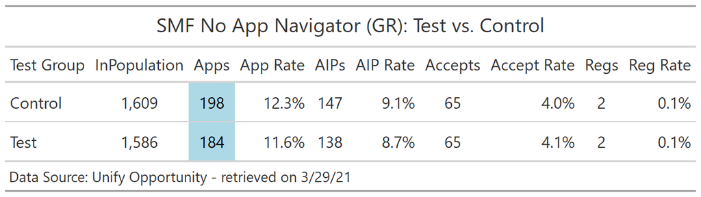

**Next Steps:**

*Closed - No Action* This experiment did not lead to more applications in the SMF No App population and the result suggest the potential for harming the application rates. A potential reason for these results might be that the student is receiving too much email communication by receiving the Navigator email on top of the emails received as part of the regular email journey and additional email followups made by the Admissions Counselors.

## Glossary of Terms

(**`SMF`**) Student Moving Forward

## Appendix

**Interpreting the Results**

- **Confidence Level:** The percentage of confidence that the result is a consequence of the change made or treatment administered and not a result of random chance. A 95% confidence interval indicates that we are 95% confident the test result is not due to random chance.
- **Statistical Significance:** A test result is said to be “statistically significant” when the difference between the results of the test and control groups is too big to have been a result of chance.
- **One-Sided vs. Two-Sided Test** A one sided test is used when we only want to prove that the *increase* in conversions (i.e. the metric) that occurred for the test group is significant; it does not consider whether any *decrease* in conversions is significant. A two-sided test evaluates the significance of the test group conversions being higher *or* lower as compared to the control. If we want to be certain that a treatment being tested does not have a negative impact on the metric, then a two-sided test should be conducted.